# Réduction de dimensionnalité et Clustering

```r
dimdesc(res.pca.d, proba=0.2)
```

```
$Dim.1

Link between the variable and the continuous variables (R-square)
=================================================================================
           correlation      p.value
Points       0.9781153 3.329637e-28
Longueur     0.7440250 2.477361e-08
Poids        0.6301326 1.010578e-05
Hauteur      0.5774317 7.726797e-05
Disque       0.5339317 3.240586e-04
Javelot      0.3263054 3.733051e-02
400m        -0.6836939 8.348930e-07
Classement  -0.6958314 4.407086e-07
110m H      -0.7216048 1.017774e-07
100m        -0.7559081 1.103071e-08

Link between the variable and the categorical variable (1-way anova)
=============================================
                    R2   p.value
Competition 0.04935451 0.1627041

Link between variable and the categories of the categorical variables
================================================================
                       Estimate   p.value
Competition=OlympicG  0.4898323 0.1627041
Competition=Decastar -0.4898323 0.1627041

$Dim.2

Link between the variable and the continuous variables (R-square)
=================================================================================
         correlation      p.value
Disque     0.6109994 2.206273e-05
Poids      0.6017990 3.154802e-05
400m       0.5649770 1.188985e-04
1500m      0.4765544 1.633487e-03
Hauteur    0.3536767 2.330036e-02
Javelot    0.3156252 4.441027e-02
110m H     0.2222426 1.625415e-01
Longueur  -0.3402188 2.951927e-02

$Dim.3

Link between the variable and the continuous variables (R-square)
=================================================================================
        correlation      p.value
1500m     0.7866061 1.084349e-09
Perche    0.6700886 1.649969e-06
100m     -0.2074460 1.931097e-01
Hauteur  -0.2441090 1.240252e-01
Javelot  -0.4048600 8.647479e-03
```

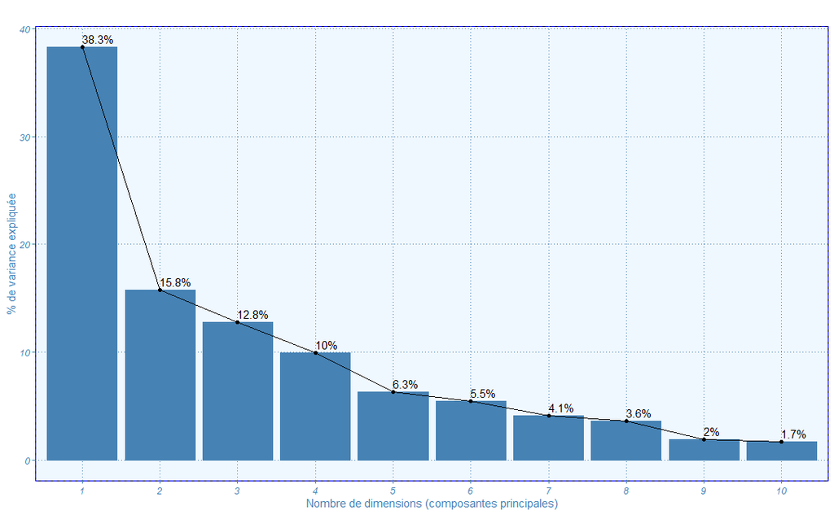

```r
# screeplot
fviz_screeplot(res.pca.d, addlabels = TRUE) +
  labs(title = "",
       x = "Nombre de dimensions (composantes principales)",
       y = "% de variance expliquée") +
  blue_theme()
```

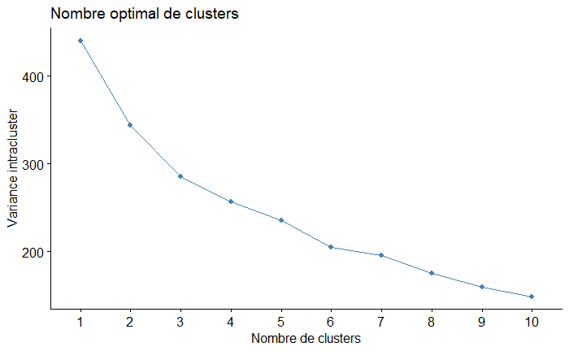

```r
# Méthode Elbow ou "du coude"
fviz_nbclust(scale(decat[,-c(11,13)]), kmeans, method = "wss") +
labs(x = "Nombre de clusters", y ="Variance intracluster", title = "Nombre optimal de clusters")
```

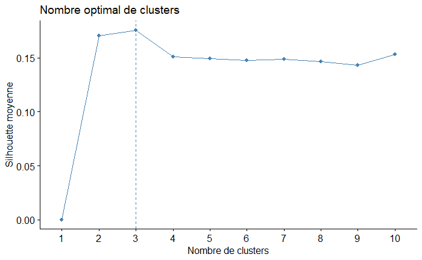

```r
# Méthode de la silhouette
fviz_nbclust(scale(decat[,-c(11,13)]), kmeans, method = "silhouette") +
labs(title = "Nombre optimal de clusters",x = "Nombre de clusters", y ="Silhouette moyenne")
```

```
Clustering k = 1,2,..., K.max (= 10): .. done
Bootstrapping, b = 1,2,..., B (= 100)  [one "." per sample]:
.................................................. 50
.................................................. 100
```

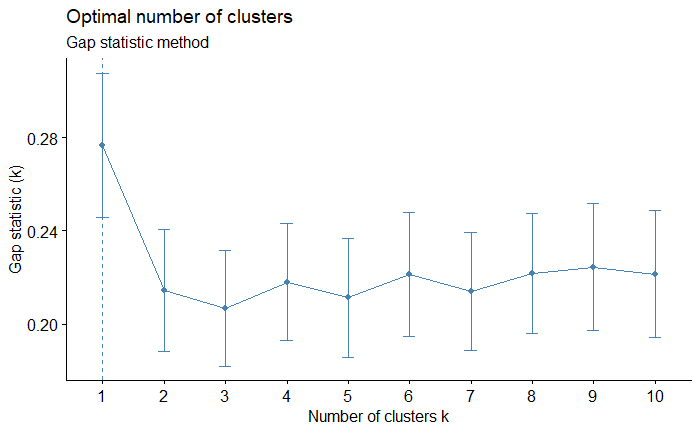

```r
fviz_nbclust(scale(decat[,-c(11,13)]), kmeans, nstart = 3, method = "gap_stat", nboot = 100)+
  labs(subtitle = "Gap statistic method")
```

```r
# Extraire les eigenvalues pour le jeu de données décathlon
eigenvalues <- res.pca.d$eig[, 1]

# Calculer la part d'inertie expliquée par chaque valeur propre
explained_variance_ratio <- eigenvalues / sum(eigenvalues)

# Calculer la méthode du bâton brisé pour le même nombre de dimensions
bstick_values <- sapply(1:length(eigenvalues), function(i) sum(1/(i:length(eigenvalues))))

# Calculer b_k pour chaque k
adjusted_bstick_values <- sapply(1:length(eigenvalues), function(k) {
  p <- length(eigenvalues)
  sum(1/(k:p)) / p
})

# Créer un tableau (data.frame) avec les eigenvalues, la part d'inertie expliquée et b_k
df2 <- data.frame(
  Eigenvalues = eigenvalues,
  ExplainedVarianceRatio = explained_variance_ratio,
  BrokenStick = bstick_values,
  AdjustedBrokenStick = adjusted_bstick_values
)

# Afficher le tableau
print(df2)
```

|  | Eigenvalues | ExplainedVarianceRatio | BrokenStick | AdjustedBrokenStick |
| --- | --- | --- | --- | --- |
| comp 1 | 4.210772e+00 | 3.827975e-01 | 3.01987734 | 0.274534304 |
| comp 2 | 1.737315e+00 | 1.579378e-01 | 2.01987734 | 0.183625213 |
| comp 3 | 1.408296e+00 | 1.280269e-01 | 1.51987734 | 0.138170668 |
| comp 4 | 1.097035e+00 | 9.973046e-02 | 1.18654401 | 0.107867637 |
| comp 5 | 6.936226e-01 | 6.305660e-02 | 0.93654401 | 0.085140365 |
| comp 6 | 6.010811e-01 | 5.464374e-02 | 0.73654401 | 0.066958547 |
| comp 7 | 4.516987e-01 | 4.106352e-02 | 0.56987734 | 0.051807031 |
| comp 8 | 3.991488e-01 | 3.628626e-02 | 0.42702020 | 0.038820018 |
| comp 9 | 2.148244e-01 | 1.952949e-02 | 0.30202020 | 0.027456382 |
| comp 10 | 1.861517e-01 | 1.692288e-02 | 0.19090909 | 0.017355372 |

[output cut: 1 more lines]

```r
NA
```

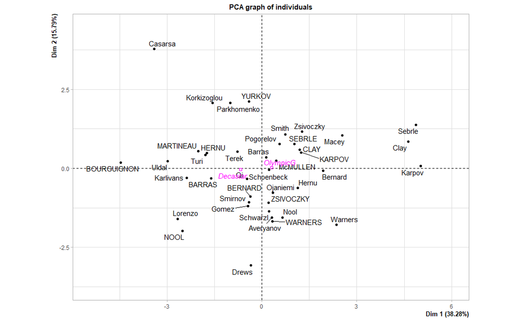

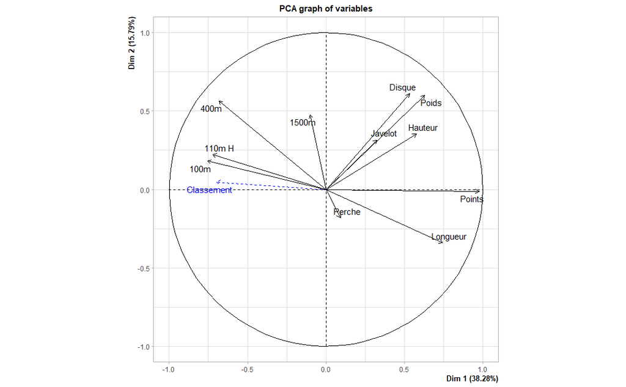

```r
res.pca.d2 <- PCA(decat, ncp = 5, quali.sup= "Competition", quanti.sup="Classement", scale =TRUE, graph=TRUE)
```

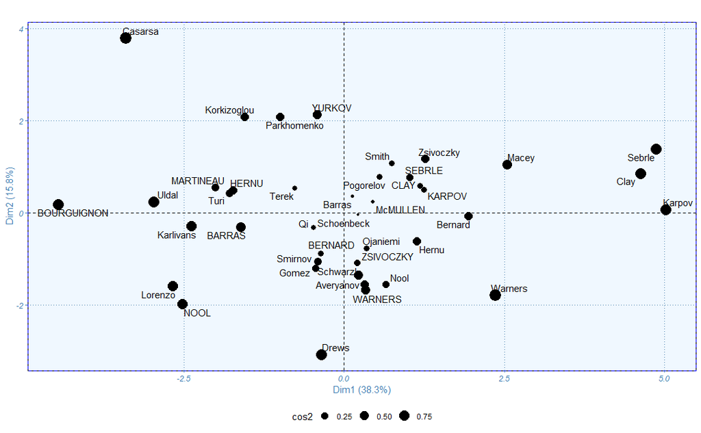

```r
fviz_pca_ind(res.pca.d2,
             # individus
             pointsize = "cos2",
             gradient.cols = inferno(100),  # Utilisation de la palette inferno
             repel = TRUE,
             title = "",
             legend.title = list(color = "contrib")
) +
  blue_theme()
```

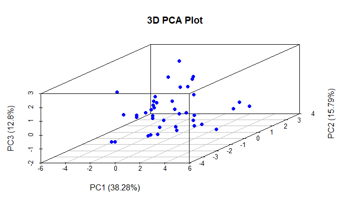

```r
x <- res.pca.d2$ind$coord[, 1]
y <- res.pca.d2$ind$coord[, 2]
z <- res.pca.d2$ind$coord[, 3]

# Pourcentage de variance expliquée
variance <- res.pca.d2$eig

# Titres des axes avec la variance
xlabel <- paste("PC1 (", round(variance[1, 2], 2), "%)", sep = "")
ylabel <- paste("PC2 (", round(variance[2, 2], 2), "%)", sep = "")
zlabel <- paste("PC3 (", round(variance[3, 2], 2), "%)", sep = "")

# Création du graphique
scatterplot3d(x, y, z, main = "3D PCA Plot", xlab = xlabel, ylab = ylabel, zlab = zlabel, color = "blue", pch = 19)
```

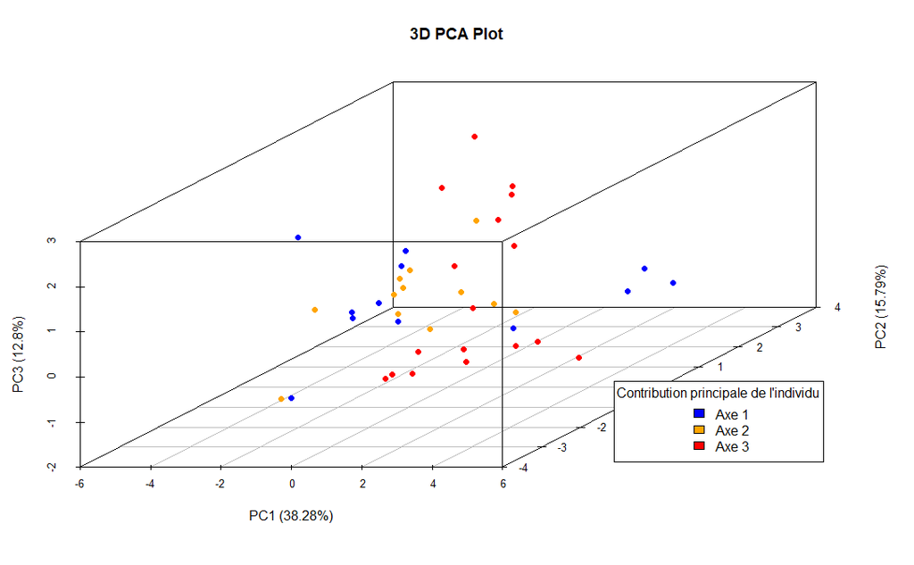

```r
# Calcul des contributions pour chaque axe
contributions <- res.pca.d2$ind$contrib

# Détermination de l'axe avec la plus grande contribution pour chaque individu
max_contrib_axis <- apply(contributions[, 1:3], 1, which.max)

x <- res.pca.d2$ind$coord[, 1]
y <- res.pca.d2$ind$coord[, 2]
z <- res.pca.d2$ind$coord[, 3]

# Assignation des couleurs
colors <- c("blue", "orange", "red")
plot_colors <- colors[max_contrib_axis]


# Titres des axes avec la variance
variance <- res.pca.d2$eig
xlabel <- paste("PC1 (", round(variance[1, 2], 2), "%)", sep = "")
ylabel <- paste("PC2 (", round(variance[2, 2], 2), "%)", sep = "")
zlabel <- paste("PC3 (", round(variance[3, 2], 2), "%)", sep = "")

# Création du graphique
scatterplot3d(x, y, z, main = "3D PCA Plot", xlab = xlabel, ylab = ylabel, zlab = zlabel, color = plot_colors, pch = 19)

# Ajout de la légende
legend("bottomright", inset=.05, title="Contribution principale de l'individu", c("Axe 1", "Axe 2", "Axe 3"), fill=colors)
```

```r
NA
NA
```

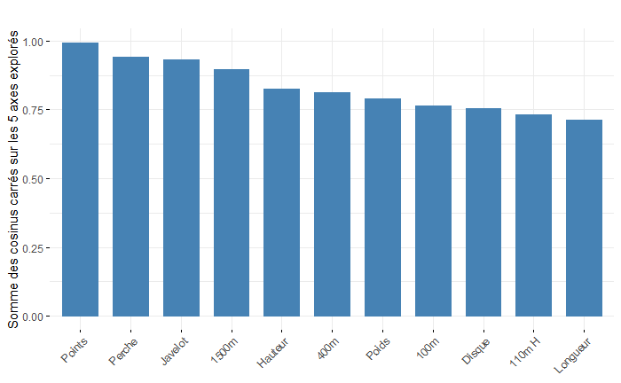

```r
# Qualité de représentation des variables sur les axes retenus de l'ACP
fviz_cos2(res.pca.d2, choice = "var", axes = 1:5) +
  labs(x="", y="Somme des cosinus carrés sur les 5 axes explorés",
       title ="")
```

```r
# création de la table de saturation
saturations_2 <- round(res.pca.d2$var$cor, 2)
saturations_2
```

```
         Dim.1 Dim.2 Dim.3 Dim.4 Dim.5
100m     -0.76  0.18 -0.21  0.04  0.34
Longueur  0.74 -0.34  0.20  0.05  0.00
Poids     0.63  0.60 -0.02  0.15  0.09
Hauteur   0.58  0.35 -0.24 -0.16  0.53
400m     -0.68  0.56  0.11  0.08 -0.08
110m H   -0.72  0.22 -0.12  0.34  0.16
Disque    0.53  0.61  0.06 -0.29 -0.09
Perche    0.09 -0.18  0.67  0.59  0.32
Javelot   0.33  0.32 -0.40  0.66 -0.35
1500m    -0.10  0.48  0.79 -0.14 -0.15
Points    0.98 -0.01 -0.05  0.17  0.08
```

```r
# Transformer les loadings en un format long
saturations_2.long <- as.data.frame(saturations_2) %>%
  rownames_to_column(var = "Variable") %>%
  pivot_longer(cols = -Variable, names_to = "CP", values_to = "Saturation")

# Trouver la variable avec la saturation la plus forte pour chaque CP
max_saturations_2 <- saturations_2.long %>%
  group_by(CP) %>%
  slice_max(order_by = abs(Saturation), n = 1) %>%
  ungroup()

# Afficher le résultat
print(max_saturations_2)
```

| Variable | CP | Saturation |
| --- | --- | --- |
| Points | Dim.1 | 0.98 |
| Disque | Dim.2 | 0.61 |
| 1500m | Dim.3 | 0.79 |
| Javelot | Dim.4 | 0.66 |
| Hauteur | Dim.5 | 0.53 |

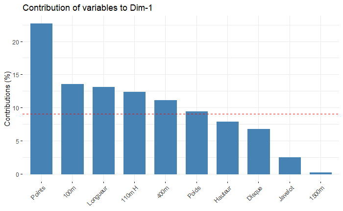

```r
# Contributions des variables à Comp1
fviz_contrib(res.pca.d2, choice = "var", axes = 1, top = 10)
```

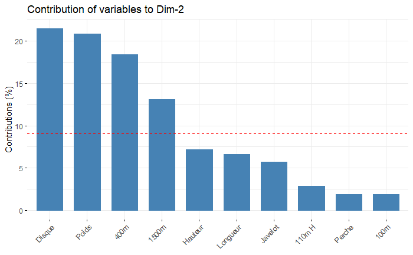

```r
# Contributions des variables à Comp2
fviz_contrib(res.pca.d2, choice = "var", axes = 2, top = 10)
```

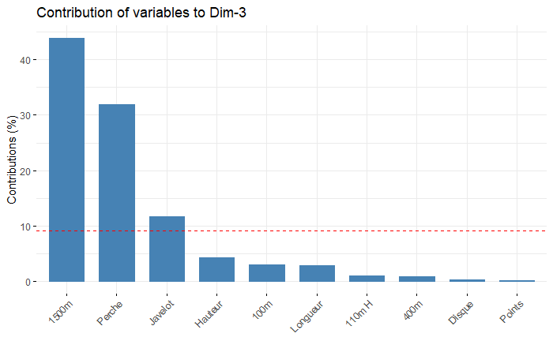

```r
# Contributions des variables à Comp3
fviz_contrib(res.pca.d2, choice = "var", axes = 3, top = 10)
```

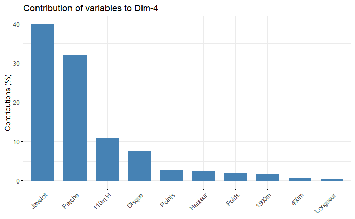

```r
# Contributions des variables à Comp4
fviz_contrib(res.pca.d2, choice = "var", axes = 4, top = 10)
```

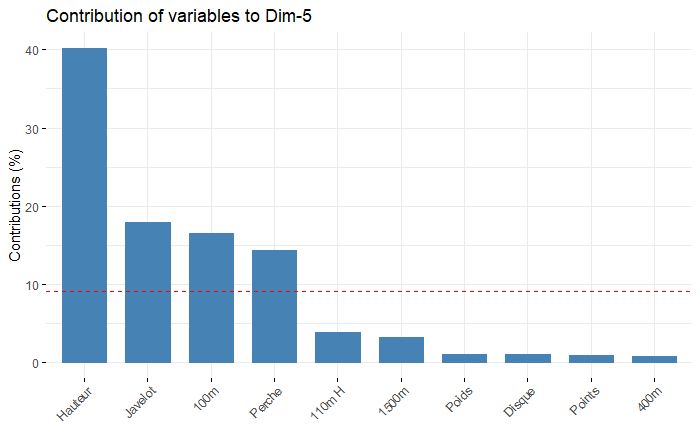

```r
# Contributions des variables à Comp5
fviz_contrib(res.pca.d2, choice = "var", axes = 5, top = 10)
```

Sur la base des saturations maximales et des contributions :

Dim1 : “high scoreur” ; la variable Points a la contribution majoritaire à l’axe 1 et est extrêmement corrélée à cette dimension (corrélation de 0.98). Cette variable pourrait donc résumer à elle seule la dimension 1.

Dim2 : “jeteur lourd” ; la variable Disque possède la contribution principale (0.61), cependant juste suivie (0.60) par la variable Poids.

Dim3 : “endurant” ; la variable 1500m possède ici la contribution et la corrélation la plus élevée.

Dim4 : “long objet dans la main” ; la variable Javelot est la variable avec la contribution et la corrélation la plus forte (0.66), mais la variable Perche reste proche (0.59)